# Previsão de Câncer de mama

#### **Sobre:**

O câncer de mama, é atualmente um dos tipos de câncer mais mortais. Iremos investigar a utilidade da aprendizagem de máquina para detecção de tumores malignos ou benignos, aplicando técnicas de machine learning e data science utilizando do repositório de Machine Learning da UCI

http://archive.ics.uci.edu/ml/machine-learning-databases/breast-cancer-wisconsin/wdbc.names

Os dados presentes no datase tratam-se de dados reais.

#### **Diretório de trabalho:**

```r
setwd('E:/projetos/previsao_cancer_de_mama')
```

#### **Librarys:**

```r
pacman::p_load(tidyverse,class,caTools,gmodels,DMwR,caret,e1071,knitr)
```

#### **Dataset:**

```r
df <- read.csv("dataset.csv")
glimpse(df)
```

```
Rows: 569
Columns: 32
$ id                <int> 87139402, 8910251, 905520, 868871, 9012568, 906539, 925291, 87880, 862989, 89827, 91485, 8711003...
$ diagnosis         <chr> "B", "B", "B", "B", "B", "B", "B", "M", "B", "B", "M", "B", "B", "B", "M", "B", "B", "B", "M", "...
$ radius_mean       <dbl> 12.320, 10.600, 11.040, 11.280, 15.190, 11.570, 11.510, 13.810, 10.490, 11.060, 20.590, 12.250, ...
$ texture_mean      <dbl> 12.39, 18.95, 16.83, 13.39, 13.21, 19.04, 23.93, 23.75, 19.29, 14.96, 21.24, 17.94, 20.74, 19.31...
$ perimeter_mean    <dbl> 78.85, 69.28, 70.92, 73.00, 97.65, 74.20, 74.52, 91.56, 67.41, 71.49, 137.80, 78.27, 85.98, 82.6...
$ area_mean         <dbl> 464.1, 346.4, 373.2, 384.8, 711.8, 409.7, 403.5, 597.8, 336.1, 373.9, 1320.0, 460.3, 536.9, 527....
$ smoothness_mean   <dbl> 0.10280, 0.09688, 0.10770, 0.11640, 0.07963, 0.08546, 0.09261, 0.13230, 0.09989, 0.10330, 0.1085...
$ compactness_mean  <dbl> 0.06981, 0.11470, 0.07804, 0.11360, 0.06934, 0.07722, 0.10210, 0.17680, 0.08578, 0.09097, 0.1644...
$ concavity_mean    <dbl> 0.039870, 0.063870, 0.030460, 0.046350, 0.033930, 0.054850, 0.111200, 0.155800, 0.029950, 0.0539...
$ points_mean       <dbl> 0.037000, 0.026420, 0.024800, 0.047960, 0.026570, 0.014280, 0.041050, 0.091760, 0.012010, 0.0334...
$ symmetry_mean     <dbl> 0.1959, 0.1922, 0.1714, 0.1771, 0.1721, 0.2031, 0.1388, 0.2251, 0.2217, 0.1776, 0.1848, 0.1970, ...
$ dimension_mean    <dbl> 0.05955, 0.06491, 0.06340, 0.06072, 0.05544, 0.06267, 0.06570, 0.07421, 0.06481, 0.06907, 0.0622...
$ radius_se         <dbl> 0.2360, 0.4505, 0.1967, 0.3384, 0.1783, 0.2864, 0.2388, 0.5648, 0.3550, 0.1601, 0.5904, 0.2200, ...
```

[output cut: 19 more lines]

Todos os dados do dataset são numéricos, com exceção da variável “diagnosis” cuja é um classificador que indicará se o conjunto de dados apontam para um tipo de câncer “benigno” ou “maligno”.

#### **Ajustando os dados:**

```r
df <- df %>% select(-id) %>%
  mutate(diagnosis = factor(diagnosis, levels = c("B","M"), labels = c(0,1))) %>%
  mutate_if(is.numeric,scale)
```

Neste ponto, foi realizado o ajuste no dataset.

Realizamos a padronização das variáveis numéricas com o “scale” e além disso foi transformado a variável “diagnosis” (variável target) em “fator” com atribuição das labels 0 e 1, onde 0 = benigno e 1 = maligno.

#### **Verificando a proporção:**

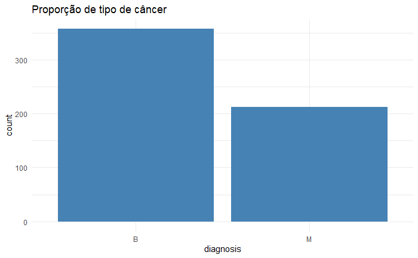

Também se faz necessário verificar o balanceamento dos dados para que o modelo seja suficientemente genérico. Neste caso, há uma proporção de 62% dos dados para “Benigno” e 37% para “Maligno”. Realizaremos o balanceamento utilizando o algoritmo SMOTE.

#### **Aplicando balanceamento:**

```r
df2 <- DMwR::SMOTE(diagnosis~.,df, perc.over = 900,perc.under = 100)
round(prop.table(table(df2$diagnosis))*100,2)
```

```
    0     1
47.37 52.63
```

#### **Dividindo dados de treino e de teste:**

```r
treino <- df2 %>% sample_frac(0.7)
teste <- df2 %>% sample_frac(0.3)
```

#### **Verificando balanceamento nos dados de treino e de teste:**

```r
round(prop.table(table(treino$diagnosis))*100,2)
```

```
    0     1
48.48 51.52
```

```r
round(prop.table(table(teste$diagnosis))*100,2)
```

```
    0     1
46.77 53.23
```

Utilizando ainda do mesmo princípio de balanceamento dos dados, é possível ver que o dataset de “treino e de”teste" estão balanceados.

#### **Modelo preditivo com o KNN:**

```r
ctrl <- trainControl(method = "repeatedcv", repeats = 3)
```

```r
knn_v1 <- caret::train(diagnosis~.,
                       data = treino,
                       method = "knn",
                       trControl = ctrl,
                       tuneLength = 20);knn_v1
```

```
k-Nearest Neighbors

2820 samples
  30 predictor
   2 classes: '0', '1'

No pre-processing
Resampling: Cross-Validated (10 fold, repeated 3 times)
Summary of sample sizes: 2537, 2539, 2537, 2539, 2537, 2539, ...
Resampling results across tuning parameters:

  k   Accuracy   Kappa
   5  0.9926692  0.9853202
   7  0.9907784  0.9815306
   9  0.9884147  0.9767971
  11  0.9841585  0.9682686
  13  0.9835671  0.9670889
  15  0.9855778  0.9711196
  17  0.9861701  0.9723036
  19  0.9852224  0.9704036
  21  0.9851059  0.9701690
  23  0.9853397  0.9706378
  25  0.9851046  0.9701720
  27  0.9839230  0.9678042
  29  0.9815585  0.9630670
  31  0.9793122  0.9585670
  33  0.9771849  0.9543023
  35  0.9775383  0.9550165
  37  0.9765964  0.9531325
  39  0.9749437  0.9498267
  41  0.9754152  0.9507748
  43  0.9752970  0.9505445

Accuracy was used to select the optimal model using the largest value.
The final value used for the model was k = 5.
```

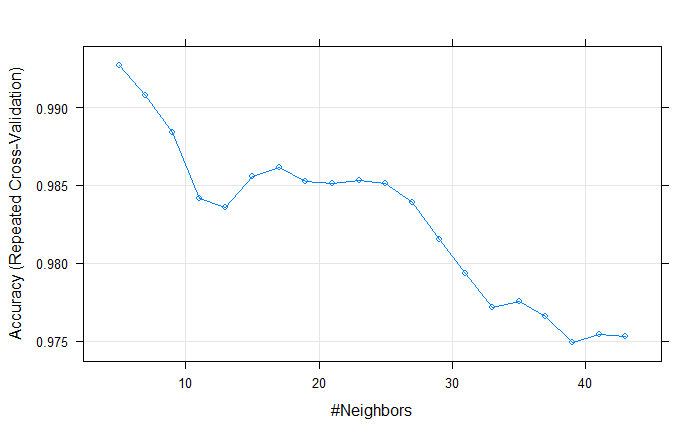

```r
plot(knn_v1)
```

O plot acima mostra qual o valor de K ideal que foi utilizado.

#### **Previsões:**

```r
previsao_knn <- predict(knn_v1,newdata=teste)
confusionMatrix(previsao_knn,teste$diagnosis)
```

```
Confusion Matrix and Statistics

          Reference
Prediction   0   1
         0 561   0
         1   4 643

               Accuracy : 0.9967
                 95% CI : (0.9915, 0.9991)
    No Information Rate : 0.5323
    P-Value [Acc > NIR] : <2e-16

                  Kappa : 0.9933

 Mcnemar's Test P-Value : 0.1336

            Sensitivity : 0.9929
            Specificity : 1.0000
         Pos Pred Value : 1.0000
         Neg Pred Value : 0.9938
             Prevalence : 0.4677
         Detection Rate : 0.4644
   Detection Prevalence : 0.4644
      Balanced Accuracy : 0.9965

       'Positive' Class : 0
```

#### **Modelo knn com métrica ROC:**

```r
controle <- trainControl(method = "repeatedcv",
                         repeats =3,
                         classProbs = TRUE,
                         summaryFunction = twoClassSummary)

df3 <- df2 %>% mutate(diagnosis = factor(diagnosis,levels = c("0","1"), labels = c("Benigno","Maligno")))
treino2 <- df3 %>%  sample_frac(0.7)
teste2 <- df3 %>% sample_frac(0.3)

knn_v2 <- caret::train(diagnosis~.,
                       data = treino2,
                       method = "knn",
                       trControl = controle,
                       metric = "ROC",
                       tuneLength = 20);knn_v2
```

```
k-Nearest Neighbors

2820 samples
  30 predictor
   2 classes: 'Benigno', 'Maligno'

No pre-processing
Resampling: Cross-Validated (10 fold, repeated 3 times)
Summary of sample sizes: 2539, 2538, 2538, 2538, 2538, 2538, ...
Resampling results across tuning parameters:

  k   ROC        Sens       Spec
   5  0.9997263  0.9913949  0.9997792
   7  0.9998713  0.9832986  0.9980103
   9  0.9997339  0.9790019  0.9980103
  11  0.9995987  0.9757075  0.9940162
  13  0.9995693  0.9784929  0.9920147
  15  0.9994978  0.9782366  0.9929051
  17  0.9994245  0.9767195  0.9913539
  19  0.9992956  0.9762144  0.9909080
  21  0.9992072  0.9749537  0.9917940
  23  0.9991291  0.9752024  0.9904621
  25  0.9991070  0.9729220  0.9893525
  27  0.9990657  0.9703967  0.9893569
  29  0.9989976  0.9696372  0.9875820
  31  0.9989471  0.9691360  0.9871405
  33  0.9988622  0.9678695  0.9831523
  35  0.9988436  0.9678734  0.9822620
  37  0.9988050  0.9668594  0.9811523
  39  0.9986870  0.9668614  0.9809345
  41  0.9986105  0.9683823  0.9807138
  43  0.9985363  0.9701558  0.9804901

ROC was used to select the optimal model using the largest value.
The final value used for the model was k = 7.
```

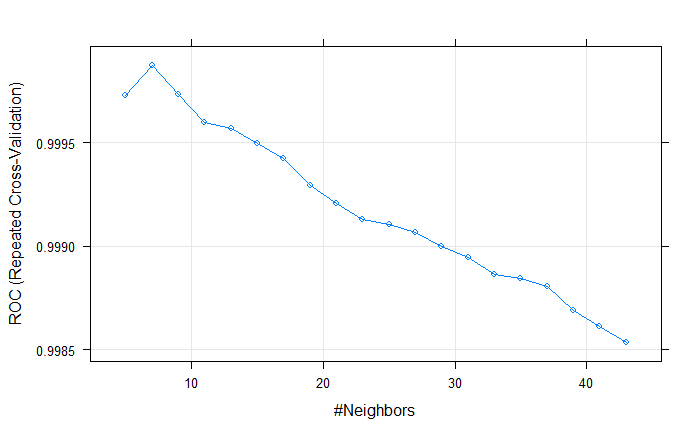

```r
plot(knn_v2)
```

O plot acima mostra qual o valor de K ideal que foi utilizado.

#### **Previsões:**

```r
previsao_knn2 <- predict(knn_v2,teste2[-1]);previsao_knn2
```

[output not shown]

[output cut: 54 more lines]

```r
confusionMatrix(previsao_knn2,teste2$diagnosis)
```

```
Confusion Matrix and Statistics

          Reference
Prediction Benigno Maligno
   Benigno     562       2
   Maligno       3     641

               Accuracy : 0.9959
                 95% CI : (0.9904, 0.9987)
    No Information Rate : 0.5323
    P-Value [Acc > NIR] : <2e-16

                  Kappa : 0.9917

 Mcnemar's Test P-Value : 1

            Sensitivity : 0.9947
            Specificity : 0.9969
         Pos Pred Value : 0.9965
         Neg Pred Value : 0.9953
             Prevalence : 0.4677
         Detection Rate : 0.4652
   Detection Prevalence : 0.4669
      Balanced Accuracy : 0.9958

       'Positive' Class : Benigno
```

#### **Modelo preditivo com o Naive Bayes:**

```r
modelo_naive <- naiveBayes(x = treino[-1],y=treino$diagnosis)
previsao <- predict(modelo_naive,teste[-1])
conf.matrix <- table(teste[,1],previsao)
confusionMatrix(conf.matrix)
```

```
Confusion Matrix and Statistics

   previsao
      0   1
  0 544  21
  1  58 585

               Accuracy : 0.9346
                 95% CI : (0.9192, 0.9479)
    No Information Rate : 0.5017
    P-Value [Acc > NIR] : < 2.2e-16

                  Kappa : 0.8692

 Mcnemar's Test P-Value : 5.115e-05

            Sensitivity : 0.9037
            Specificity : 0.9653
         Pos Pred Value : 0.9628
         Neg Pred Value : 0.9098
             Prevalence : 0.4983
         Detection Rate : 0.4503
   Detection Prevalence : 0.4677
      Balanced Accuracy : 0.9345

       'Positive' Class : 0
```

#### **Modelo preditivo com regressão logística:**

```r
control <- trainControl(method = "repeatedcv", number = 10, repeats = 2)
modelo_reg_log <- train(diagnosis~., data = treino, method = "glm", trControl = control)
```

#### **Visualizando variáveis mais importantes:**

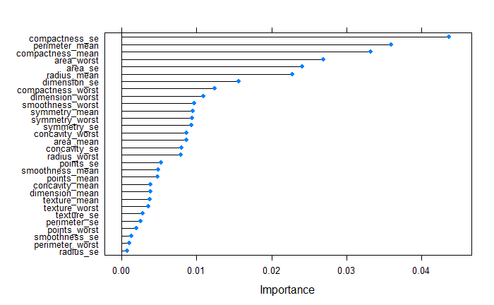

```r
importance <- varImp(modelo_reg_log, scale = FALSE);plot(importance)
```

#### **Fazendo previsões:**

```r
previsoes <- predict(modelo_reg_log, teste[-1])
```

#### **Avaliando o modelo:**

```r
confusionMatrix(table(data = previsoes, reference = teste[,1]), positive = "1")
```

```
Confusion Matrix and Statistics

    reference
data   0   1
   0 565   0
   1   0 643

               Accuracy : 1
                 95% CI : (0.997, 1)
    No Information Rate : 0.5323
    P-Value [Acc > NIR] : < 2.2e-16

                  Kappa : 1

 Mcnemar's Test P-Value : NA

            Sensitivity : 1.0000
            Specificity : 1.0000
         Pos Pred Value : 1.0000
         Neg Pred Value : 1.0000
             Prevalence : 0.5323
         Detection Rate : 0.5323
   Detection Prevalence : 0.5323
      Balanced Accuracy : 1.0000

       'Positive' Class : 1
```

O Modelo com regressão logística acertou 100% dos dados, ou seja, não tivemos nenhum falso positivo e nenhum falso negativo, o que é ótimo devido ao contexto do dataset tratar de diagnóstico de câncer de mama.